# Data Science for Public Health - Use Stata with R Markdown

H. Langet, S. Lwambura and C.Festo

2022-09-09

# 1 Load libraries

Load all the R libraries that are needed to run this document.

## 1.1 Load RStata

The `RStata` package is a simple R / Stata interface which enable the user to:

- execute Stata commands (both inline and from a .do file) from R;
- pass a data.frame to Stata;
- return a data.frame to R;
- include Stata chunks in knitr documents (however each chunk is independent from the others; feature tested with LaTeX/Linux).

```r
library(RStata)
```

## 1.2 Load Haven

The `Haven` package enables R to read and write various data formats used by other statistical packages by wrapping the `ReadStat` C library. `Haven` currently supports SAS, SPSS and Stata.

```r
library(haven)
```

## 1.3 Load Psych

```r
library(psych)
```

# 2 Execute Stata commands from R

## 2.1 Execute a command line

The `stata` function from the `RStata` library allows you to execute Stata commands from your R session.

```r
RStata::stata('di "This sentence is displayed using Stata"')
```

. di “This sentence is displayed using Stata” This sentence is displayed using Stata

## 2.2 Execute an entire .do file

You can execute an entire .do file.

```r
RStata::stata("demo_do_file.do")
```

. *Created for demonstration purpose one . // Do files can also be tracked via git . . sysuse auto, (1978 Automobile Data) . . desc

[output not shown]

# 3 Use Stata datasets

## 3.1 Return R data frame objects from Stata commands

You need to set the `data.out` parameter to `TRUE` when using the `stata` function to return an R data frame object that can be used within the R session.

For those who have never used R before, In R we need to store the dataset (also referred to as dataframe) into a variable in order to be able to use the dataset. the `<-` is an assignment operation, `=` can also be used.

In the example below, the automobile dataset shipped with Stata is loaded and the returned data frame is stored in a variable named `df1`.

```r
df1 <- RStata::stata("sysuse auto",
                     data.out = TRUE)
```

. sysuse auto (1978 Automobile Data)

You can use the returned data frame in R. For instance, you can generate a simple formatted table to display the content of the returned data frame by using the `kable` function from the `knitr` package.

```r
knitr::kable(df1)
```

| make | price | mpg | rep78 | headroom | trunk | weight | length | turn | displacement | gear_ratio | foreign |
| --- | --- | --- | --- | --- | --- | --- | --- | --- | --- | --- | --- |
| AMC Concord | 4099 | 22 | 3 | 2.5 | 11 | 2930 | 186 | 40 | 121 | 3.58 | Domestic |
| AMC Pacer | 4749 | 17 | 3 | 3.0 | 11 | 3350 | 173 | 40 | 258 | 2.53 | Domestic |
| AMC Spirit | 3799 | 22 | NA | 3.0 | 12 | 2640 | 168 | 35 | 121 | 3.08 | Domestic |
| Buick Century | 4816 | 20 | 3 | 4.5 | 16 | 3250 | 196 | 40 | 196 | 2.93 | Domestic |
| Buick Electra | 7827 | 15 | 4 | 4.0 | 20 | 4080 | 222 | 43 | 350 | 2.41 | Domestic |
| Buick LeSabre | 5788 | 18 | 3 | 4.0 | 21 | 3670 | 218 | 43 | 231 | 2.73 | Domestic |
| Buick Opel | 4453 | 26 | NA | 3.0 | 10 | 2230 | 170 | 34 | 304 | 2.87 | Domestic |
| Buick Regal | 5189 | 20 | 3 | 2.0 | 16 | 3280 | 200 | 42 | 196 | 2.93 | Domestic |
| Buick Riviera | 10372 | 16 | 3 | 3.5 | 17 | 3880 | 207 | 43 | 231 | 2.93 | Domestic |
| Buick Skylark | 4082 | 19 | 3 | 3.5 | 13 | 3400 | 200 | 42 | 231 | 3.08 | Domestic |
| Cad. Deville | 11385 | 14 | 3 | 4.0 | 20 | 4330 | 221 | 44 | 425 | 2.28 | Domestic |
| Cad. Eldorado | 14500 | 14 | 2 | 3.5 | 16 | 3900 | 204 | 43 | 350 | 2.19 | Domestic |
| Cad. Seville | 15906 | 21 | 3 | 3.0 | 13 | 4290 | 204 | 45 | 350 | 2.24 | Domestic |
| Chev. Chevette | 3299 | 29 | 3 | 2.5 | 9 | 2110 | 163 | 34 | 231 | 2.93 | Domestic |
| Chev. Impala | 5705 | 16 | 4 | 4.0 | 20 | 3690 | 212 | 43 | 250 | 2.56 | Domestic |
| Chev. Malibu | 4504 | 22 | 3 | 3.5 | 17 | 3180 | 193 | 31 | 200 | 2.73 | Domestic |
| Chev. Monte Carlo | 5104 | 22 | 2 | 2.0 | 16 | 3220 | 200 | 41 | 200 | 2.73 | Domestic |
| Chev. Monza | 3667 | 24 | 2 | 2.0 | 7 | 2750 | 179 | 40 | 151 | 2.73 | Domestic |
| Chev. Nova | 3955 | 19 | 3 | 3.5 | 13 | 3430 | 197 | 43 | 250 | 2.56 | Domestic |
| Dodge Colt | 3984 | 30 | 5 | 2.0 | 8 | 2120 | 163 | 35 | 98 | 3.54 | Domestic |
| Dodge Diplomat | 4010 | 18 | 2 | 4.0 | 17 | 3600 | 206 | 46 | 318 | 2.47 | Domestic |
| Dodge Magnum | 5886 | 16 | 2 | 4.0 | 17 | 3600 | 206 | 46 | 318 | 2.47 | Domestic |
| Dodge St. Regis | 6342 | 17 | 2 | 4.5 | 21 | 3740 | 220 | 46 | 225 | 2.94 | Domestic |
| Ford Fiesta | 4389 | 28 | 4 | 1.5 | 9 | 1800 | 147 | 33 | 98 | 3.15 | Domestic |
| Ford Mustang | 4187 | 21 | 3 | 2.0 | 10 | 2650 | 179 | 43 | 140 | 3.08 | Domestic |
| Linc. Continental | 11497 | 12 | 3 | 3.5 | 22 | 4840 | 233 | 51 | 400 | 2.47 | Domestic |
| Linc. Mark V | 13594 | 12 | 3 | 2.5 | 18 | 4720 | 230 | 48 | 400 | 2.47 | Domestic |
| Linc. Versailles | 13466 | 14 | 3 | 3.5 | 15 | 3830 | 201 | 41 | 302 | 2.47 | Domestic |
| Merc. Bobcat | 3829 | 22 | 4 | 3.0 | 9 | 2580 | 169 | 39 | 140 | 2.73 | Domestic |
| Merc. Cougar | 5379 | 14 | 4 | 3.5 | 16 | 4060 | 221 | 48 | 302 | 2.75 | Domestic |
| Merc. Marquis | 6165 | 15 | 3 | 3.5 | 23 | 3720 | 212 | 44 | 302 | 2.26 | Domestic |
| Merc. Monarch | 4516 | 18 | 3 | 3.0 | 15 | 3370 | 198 | 41 | 250 | 2.43 | Domestic |
| Merc. XR-7 | 6303 | 14 | 4 | 3.0 | 16 | 4130 | 217 | 45 | 302 | 2.75 | Domestic |
| Merc. Zephyr | 3291 | 20 | 3 | 3.5 | 17 | 2830 | 195 | 43 | 140 | 3.08 | Domestic |
| Olds 98 | 8814 | 21 | 4 | 4.0 | 20 | 4060 | 220 | 43 | 350 | 2.41 | Domestic |
| Olds Cutl Supr | 5172 | 19 | 3 | 2.0 | 16 | 3310 | 198 | 42 | 231 | 2.93 | Domestic |
| Olds Cutlass | 4733 | 19 | 3 | 4.5 | 16 | 3300 | 198 | 42 | 231 | 2.93 | Domestic |
| Olds Delta 88 | 4890 | 18 | 4 | 4.0 | 20 | 3690 | 218 | 42 | 231 | 2.73 | Domestic |
| Olds Omega | 4181 | 19 | 3 | 4.5 | 14 | 3370 | 200 | 43 | 231 | 3.08 | Domestic |
| Olds Starfire | 4195 | 24 | 1 | 2.0 | 10 | 2730 | 180 | 40 | 151 | 2.73 | Domestic |
| Olds Toronado | 10371 | 16 | 3 | 3.5 | 17 | 4030 | 206 | 43 | 350 | 2.41 | Domestic |
| Plym. Arrow | 4647 | 28 | 3 | 2.0 | 11 | 3260 | 170 | 37 | 156 | 3.05 | Domestic |
| Plym. Champ | 4425 | 34 | 5 | 2.5 | 11 | 1800 | 157 | 37 | 86 | 2.97 | Domestic |
| Plym. Horizon | 4482 | 25 | 3 | 4.0 | 17 | 2200 | 165 | 36 | 105 | 3.37 | Domestic |
| Plym. Sapporo | 6486 | 26 | NA | 1.5 | 8 | 2520 | 182 | 38 | 119 | 3.54 | Domestic |
| Plym. Volare | 4060 | 18 | 2 | 5.0 | 16 | 3330 | 201 | 44 | 225 | 3.23 | Domestic |
| Pont. Catalina | 5798 | 18 | 4 | 4.0 | 20 | 3700 | 214 | 42 | 231 | 2.73 | Domestic |
| Pont. Firebird | 4934 | 18 | 1 | 1.5 | 7 | 3470 | 198 | 42 | 231 | 3.08 | Domestic |
| Pont. Grand Prix | 5222 | 19 | 3 | 2.0 | 16 | 3210 | 201 | 45 | 231 | 2.93 | Domestic |
| Pont. Le Mans | 4723 | 19 | 3 | 3.5 | 17 | 3200 | 199 | 40 | 231 | 2.93 | Domestic |
| Pont. Phoenix | 4424 | 19 | NA | 3.5 | 13 | 3420 | 203 | 43 | 231 | 3.08 | Domestic |
| Pont. Sunbird | 4172 | 24 | 2 | 2.0 | 7 | 2690 | 179 | 41 | 151 | 2.73 | Domestic |
| Audi 5000 | 9690 | 17 | 5 | 3.0 | 15 | 2830 | 189 | 37 | 131 | 3.20 | Foreign |
| Audi Fox | 6295 | 23 | 3 | 2.5 | 11 | 2070 | 174 | 36 | 97 | 3.70 | Foreign |
| BMW 320i | 9735 | 25 | 4 | 2.5 | 12 | 2650 | 177 | 34 | 121 | 3.64 | Foreign |
| Datsun 200 | 6229 | 23 | 4 | 1.5 | 6 | 2370 | 170 | 35 | 119 | 3.89 | Foreign |
| Datsun 210 | 4589 | 35 | 5 | 2.0 | 8 | 2020 | 165 | 32 | 85 | 3.70 | Foreign |
| Datsun 510 | 5079 | 24 | 4 | 2.5 | 8 | 2280 | 170 | 34 | 119 | 3.54 | Foreign |
| Datsun 810 | 8129 | 21 | 4 | 2.5 | 8 | 2750 | 184 | 38 | 146 | 3.55 | Foreign |
| Fiat Strada | 4296 | 21 | 3 | 2.5 | 16 | 2130 | 161 | 36 | 105 | 3.37 | Foreign |
| Honda Accord | 5799 | 25 | 5 | 3.0 | 10 | 2240 | 172 | 36 | 107 | 3.05 | Foreign |
| Honda Civic | 4499 | 28 | 4 | 2.5 | 5 | 1760 | 149 | 34 | 91 | 3.30 | Foreign |
| Mazda GLC | 3995 | 30 | 4 | 3.5 | 11 | 1980 | 154 | 33 | 86 | 3.73 | Foreign |
| Peugeot 604 | 12990 | 14 | NA | 3.5 | 14 | 3420 | 192 | 38 | 163 | 3.58 | Foreign |
| Renault Le Car | 3895 | 26 | 3 | 3.0 | 10 | 1830 | 142 | 34 | 79 | 3.72 | Foreign |
| Subaru | 3798 | 35 | 5 | 2.5 | 11 | 2050 | 164 | 36 | 97 | 3.81 | Foreign |
| Toyota Celica | 5899 | 18 | 5 | 2.5 | 14 | 2410 | 174 | 36 | 134 | 3.06 | Foreign |
| Toyota Corolla | 3748 | 31 | 5 | 3.0 | 9 | 2200 | 165 | 35 | 97 | 3.21 | Foreign |
| Toyota Corona | 5719 | 18 | 5 | 2.0 | 11 | 2670 | 175 | 36 | 134 | 3.05 | Foreign |
| VW Dasher | 7140 | 23 | 4 | 2.5 | 12 | 2160 | 172 | 36 | 97 | 3.74 | Foreign |
| VW Diesel | 5397 | 41 | 5 | 3.0 | 15 | 2040 | 155 | 35 | 90 | 3.78 | Foreign |
| VW Rabbit | 4697 | 25 | 4 | 3.0 | 15 | 1930 | 155 | 35 | 89 | 3.78 | Foreign |
| VW Scirocco | 6850 | 25 | 4 | 2.0 | 16 | 1990 | 156 | 36 | 97 | 3.78 | Foreign |
| Volvo 260 | 11995 | 17 | 5 | 2.5 | 14 | 3170 | 193 | 37 | 163 | 2.98 | Foreign |

## 3.2 Read Stata DTA files

You can load Stata .dta data by using the `read_dta` function from the `haven` package.

```r
df2 <- haven::read_dta("iris.dta")
```

Display the dataframe in a simple table

```r
knitr::kable(df2)
```

| sepallength | sepalwidth | petallength | petalwidth | species |
| --- | --- | --- | --- | --- |
| 5.1 | 3.5 | 1.4 | 0.2 | setosa |
| 4.9 | 3.0 | 1.4 | 0.2 | setosa |
| 4.7 | 3.2 | 1.3 | 0.2 | setosa |
| 4.6 | 3.1 | 1.5 | 0.2 | setosa |
| 5.0 | 3.6 | 1.4 | 0.2 | setosa |
| 5.4 | 3.9 | 1.7 | 0.4 | setosa |
| 4.6 | 3.4 | 1.4 | 0.3 | setosa |
| 5.0 | 3.4 | 1.5 | 0.2 | setosa |
| 4.4 | 2.9 | 1.4 | 0.2 | setosa |
| 4.9 | 3.1 | 1.5 | 0.1 | setosa |
| 5.4 | 3.7 | 1.5 | 0.2 | setosa |
| 4.8 | 3.4 | 1.6 | 0.2 | setosa |
| 4.8 | 3.0 | 1.4 | 0.1 | setosa |
| 4.3 | 3.0 | 1.1 | 0.1 | setosa |
| 5.8 | 4.0 | 1.2 | 0.2 | setosa |
| 5.7 | 4.4 | 1.5 | 0.4 | setosa |
| 5.4 | 3.9 | 1.3 | 0.4 | setosa |
| 5.1 | 3.5 | 1.4 | 0.3 | setosa |
| 5.7 | 3.8 | 1.7 | 0.3 | setosa |
| 5.1 | 3.8 | 1.5 | 0.3 | setosa |
| 5.4 | 3.4 | 1.7 | 0.2 | setosa |
| 5.1 | 3.7 | 1.5 | 0.4 | setosa |
| 4.6 | 3.6 | 1.0 | 0.2 | setosa |
| 5.1 | 3.3 | 1.7 | 0.5 | setosa |
| 4.8 | 3.4 | 1.9 | 0.2 | setosa |
| 5.0 | 3.0 | 1.6 | 0.2 | setosa |
| 5.0 | 3.4 | 1.6 | 0.4 | setosa |
| 5.2 | 3.5 | 1.5 | 0.2 | setosa |
| 5.2 | 3.4 | 1.4 | 0.2 | setosa |
| 4.7 | 3.2 | 1.6 | 0.2 | setosa |

[output cut: 120 more lines]

# 4 Combine Stata and R

It can be very handy to combine Stata and R, for instance if you want to clean your data in Stata and then plot it in R using ggplot2, or vice-versa.

## 4.1 Use Stata after R

```r
RStata::stata("codebook",
              data.in = df2)
```

. codebook

| sepallength sepallength |
| --- |

```
              type:  numeric (double)

             range:  [4.3,7.9]                    units:  .1
     unique values:  35                       missing .:  0/150

              mean:   5.84333
          std. dev:   .828066

       percentiles:        10%       25%       50%       75%       90%
                           4.8       5.1       5.8       6.4       6.9
```

| sepalwidth sepalwidth |
| --- |

```
              type:  numeric (double)

             range:  [2,4.4]                      units:  .1
     unique values:  23                       missing .:  0/150

              mean:   3.05733
          std. dev:   .435866

       percentiles:        10%       25%       50%       75%       90%
                           2.5       2.8         3       3.3      3.65
```

| petallength petallength |
| --- |

```
              type:  numeric (double)

             range:  [1,6.9]                      units:  .1
     unique values:  43                       missing .:  0/150

              mean:     3.758
          std. dev:    1.7653

       percentiles:        10%       25%       50%       75%       90%
                           1.4       1.6      4.35       5.1       5.8
```

| petalwidth petalwidth |
| --- |

```
              type:  numeric (double)

             range:  [.1,2.5]                     units:  .1
     unique values:  22                       missing .:  0/150

              mean:   1.19933
          std. dev:   .762238

       percentiles:        10%       25%       50%       75%       90%
                            .2        .3       1.3       1.8       2.2
```

| species species |
| --- |

```
              type:  string (str10)

     unique values:  3                        missing "":  0/150

        tabulation:  Freq.  Value
                        50  "setosa"
                        50  "versicolor"
                        50  "virginica"
```

## 4.2 Use R after Stata

```r
df3 <- mtcars
# descriptive statistics summary
summary1 <- psych::describe(df3)
knitr::kable(summary1)
```

|  | vars | n | mean | sd | median | trimmed | mad | min | max | range | skew | kurtosis | se |
| --- | --- | --- | --- | --- | --- | --- | --- | --- | --- | --- | --- | --- | --- |
| mpg | 1 | 32 | 20.090625 | 6.0269481 | 19.200 | 19.6961538 | 5.4114900 | 10.400 | 33.900 | 23.500 | 0.6106550 | -0.3727660 | 1.0654240 |
| cyl | 2 | 32 | 6.187500 | 1.7859216 | 6.000 | 6.2307692 | 2.9652000 | 4.000 | 8.000 | 4.000 | -0.1746119 | -1.7621198 | 0.3157093 |
| disp | 3 | 32 | 230.721875 | 123.9386938 | 196.300 | 222.5230769 | 140.4763500 | 71.100 | 472.000 | 400.900 | 0.3816570 | -1.2072119 | 21.9094727 |
| hp | 4 | 32 | 146.687500 | 68.5628685 | 123.000 | 141.1923077 | 77.0952000 | 52.000 | 335.000 | 283.000 | 0.7260237 | -0.1355511 | 12.1203173 |
| drat | 5 | 32 | 3.596563 | 0.5346787 | 3.695 | 3.5792308 | 0.7042350 | 2.760 | 4.930 | 2.170 | 0.2659039 | -0.7147006 | 0.0945187 |
| wt | 6 | 32 | 3.217250 | 0.9784574 | 3.325 | 3.1526923 | 0.7672455 | 1.513 | 5.424 | 3.911 | 0.4231465 | -0.0227108 | 0.1729685 |
| qsec | 7 | 32 | 17.848750 | 1.7869432 | 17.710 | 17.8276923 | 1.4158830 | 14.500 | 22.900 | 8.400 | 0.3690453 | 0.3351142 | 0.3158899 |
| vs | 8 | 32 | 0.437500 | 0.5040161 | 0.000 | 0.4230769 | 0.0000000 | 0.000 | 1.000 | 1.000 | 0.2402577 | -2.0019376 | 0.0890983 |
| am | 9 | 32 | 0.406250 | 0.4989909 | 0.000 | 0.3846154 | 0.0000000 | 0.000 | 1.000 | 1.000 | 0.3640159 | -1.9247414 | 0.0882100 |
| gear | 10 | 32 | 3.687500 | 0.7378041 | 4.000 | 3.6153846 | 1.4826000 | 3.000 | 5.000 | 2.000 | 0.5288545 | -1.0697507 | 0.1304266 |
| carb | 11 | 32 | 2.812500 | 1.6152000 | 2.000 | 2.6538462 | 1.4826000 | 1.000 | 8.000 | 7.000 | 1.0508738 | 1.2570431 | 0.2855297 |

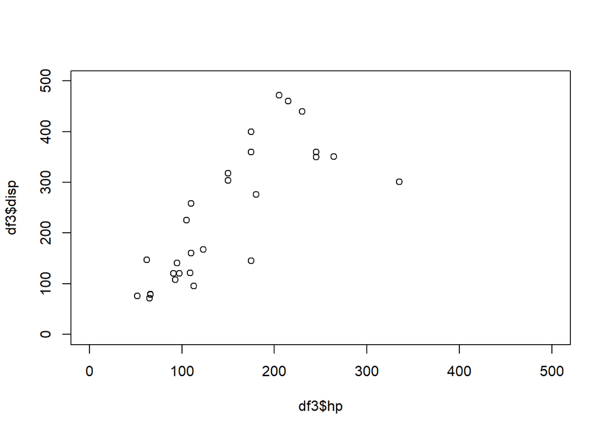

```r
# Plot
plot(df3$hp, df3$disp, xlim=c(0,500), ylim=c(0,500))
```

```r
# Codebook / data structure
RStata::stata("codebook",
              data.in = df2)
```

. codebook

| sepallength sepallength |
| --- |

```
              type:  numeric (double)

             range:  [4.3,7.9]                    units:  .1
     unique values:  35                       missing .:  0/150

              mean:   5.84333
          std. dev:   .828066

       percentiles:        10%       25%       50%       75%       90%
                           4.8       5.1       5.8       6.4       6.9
```

| sepalwidth sepalwidth |
| --- |

```
              type:  numeric (double)

             range:  [2,4.4]                      units:  .1
     unique values:  23                       missing .:  0/150

              mean:   3.05733
          std. dev:   .435866

       percentiles:        10%       25%       50%       75%       90%
                           2.5       2.8         3       3.3      3.65
```

| petallength petallength |
| --- |

```
              type:  numeric (double)

             range:  [1,6.9]                      units:  .1
     unique values:  43                       missing .:  0/150

              mean:     3.758
          std. dev:    1.7653

       percentiles:        10%       25%       50%       75%       90%
                           1.4       1.6      4.35       5.1       5.8
```

| petalwidth petalwidth |
| --- |

```
              type:  numeric (double)

             range:  [.1,2.5]                     units:  .1
     unique values:  22                       missing .:  0/150

              mean:   1.19933
          std. dev:   .762238

       percentiles:        10%       25%       50%       75%       90%
                            .2        .3       1.3       1.8       2.2
```

| species species |
| --- |

```
              type:  string (str10)

     unique values:  3                        missing "":  0/150

        tabulation:  Freq.  Value
                        50  "setosa"
                        50  "versicolor"
                        50  "virginica"
```

Use the `drop` command to remove observations where the the variable `disp` is below 200.

```r
df4 <- RStata::stata("drop if disp <= 200",
                     data.in = df3,
                     data.out = TRUE)
```

. drop if disp <= 200 (16 observations deleted)

```r
summary2 <- psych::describe(df4)
knitr::kable(summary2)
```

|  | vars | n | mean | sd | median | trimmed | mad | min | max | range | skew | kurtosis | se |
| --- | --- | --- | --- | --- | --- | --- | --- | --- | --- | --- | --- | --- | --- |
| mpg | 1 | 16 | 15.681250 | 2.9267089 | 15.35 | 15.6500000 | 2.2239000 | 10.40 | 21.400 | 11.000 | -0.0881655 | -0.4954038 | 0.7316772 |
| cyl | 2 | 16 | 7.750000 | 0.6831301 | 8.00 | 7.8571429 | 0.0000000 | 6.00 | 8.000 | 2.000 | -2.0585392 | 2.3989955 | 0.1707825 |
| disp | 3 | 16 | 339.150000 | 73.9587092 | 334.00 | 337.8142857 | 86.2873200 | 225.00 | 472.000 | 247.000 | 0.3845110 | -1.1039446 | 18.4896773 |
| hp | 4 | 16 | 196.500000 | 58.8217647 | 180.00 | 193.1428571 | 48.1845000 | 105.00 | 335.000 | 230.000 | 0.4880522 | -0.1952105 | 14.7054412 |
| drat | 5 | 16 | 3.190625 | 0.3670689 | 3.08 | 3.1478571 | 0.1556730 | 2.76 | 4.220 | 1.460 | 1.3874268 | 1.4684154 | 0.0917672 |
| wt | 6 | 16 | 3.916500 | 0.7435644 | 3.65 | 3.8621429 | 0.3002265 | 3.17 | 5.424 | 2.254 | 1.1378141 | -0.2913634 | 0.1858911 |
| qsec | 7 | 16 | 17.154375 | 1.5332622 | 17.35 | 17.1250000 | 0.8228430 | 14.50 | 20.220 | 5.720 | -0.0110136 | -0.4973625 | 0.3833155 |
| vs | 8 | 16 | 0.125000 | 0.3415650 | 0.00 | 0.0714286 | 0.0000000 | 0.00 | 1.000 | 1.000 | 2.0585392 | 2.3989955 | 0.0853913 |
| am | 9 | 16 | 0.125000 | 0.3415650 | 0.00 | 0.0714286 | 0.0000000 | 0.00 | 1.000 | 1.000 | 2.0585392 | 2.3989955 | 0.0853913 |
| gear | 10 | 16 | 3.250000 | 0.6831301 | 3.00 | 3.1428571 | 0.0000000 | 3.00 | 5.000 | 2.000 | 2.0585392 | 2.3989955 | 0.1707825 |
| carb | 11 | 16 | 3.187500 | 1.6820127 | 3.00 | 3.0000000 | 1.4826000 | 1.00 | 8.000 | 7.000 | 1.1429532 | 1.6285245 | 0.4205032 |

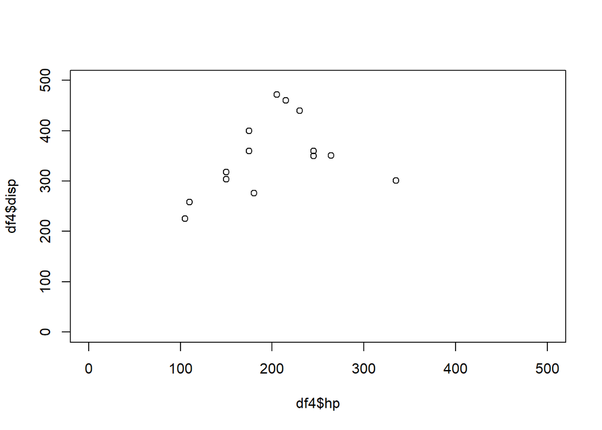

```r
plot(df4$hp, df4$disp, xlim=c(0,500), ylim=c(0,500))
```

an additional example for using stata from within R is adding new variable in a dataset. Using the df2 data we imported we can add a new variable called **sepalarea** using the stata command. Note we have to specify the `data.out` to be able to return the resulting dataset

```r
df2 <- RStata::stata("gen sepalarea=sepallength*sepalwidth",
                     data.in=df2,
                     data.out=TRUE)
```

. gen sepalarea=sepallength*sepalwidth

```r
df2 <- RStata::stata("gen new=0",
                     data.in=df2,
                     data.out=TRUE)
```

. gen new=0

```r
knitr::kable(df2)
```

| sepallength | sepalwidth | petallength | petalwidth | species | sepalarea | new |
| --- | --- | --- | --- | --- | --- | --- |
| 5.1 | 3.5 | 1.4 | 0.2 | setosa | 17.85 | 0 |
| 4.9 | 3.0 | 1.4 | 0.2 | setosa | 14.70 | 0 |
| 4.7 | 3.2 | 1.3 | 0.2 | setosa | 15.04 | 0 |
| 4.6 | 3.1 | 1.5 | 0.2 | setosa | 14.26 | 0 |
| 5.0 | 3.6 | 1.4 | 0.2 | setosa | 18.00 | 0 |
| 5.4 | 3.9 | 1.7 | 0.4 | setosa | 21.06 | 0 |
| 4.6 | 3.4 | 1.4 | 0.3 | setosa | 15.64 | 0 |
| 5.0 | 3.4 | 1.5 | 0.2 | setosa | 17.00 | 0 |
| 4.4 | 2.9 | 1.4 | 0.2 | setosa | 12.76 | 0 |
| 4.9 | 3.1 | 1.5 | 0.1 | setosa | 15.19 | 0 |
| 5.4 | 3.7 | 1.5 | 0.2 | setosa | 19.98 | 0 |
| 4.8 | 3.4 | 1.6 | 0.2 | setosa | 16.32 | 0 |
| 4.8 | 3.0 | 1.4 | 0.1 | setosa | 14.40 | 0 |
| 4.3 | 3.0 | 1.1 | 0.1 | setosa | 12.90 | 0 |
| 5.8 | 4.0 | 1.2 | 0.2 | setosa | 23.20 | 0 |
| 5.7 | 4.4 | 1.5 | 0.4 | setosa | 25.08 | 0 |
| 5.4 | 3.9 | 1.3 | 0.4 | setosa | 21.06 | 0 |
| 5.1 | 3.5 | 1.4 | 0.3 | setosa | 17.85 | 0 |
| 5.7 | 3.8 | 1.7 | 0.3 | setosa | 21.66 | 0 |
| 5.1 | 3.8 | 1.5 | 0.3 | setosa | 19.38 | 0 |
| 5.4 | 3.4 | 1.7 | 0.2 | setosa | 18.36 | 0 |
| 5.1 | 3.7 | 1.5 | 0.4 | setosa | 18.87 | 0 |
| 4.6 | 3.6 | 1.0 | 0.2 | setosa | 16.56 | 0 |
| 5.1 | 3.3 | 1.7 | 0.5 | setosa | 16.83 | 0 |
| 4.8 | 3.4 | 1.9 | 0.2 | setosa | 16.32 | 0 |
| 5.0 | 3.0 | 1.6 | 0.2 | setosa | 15.00 | 0 |
| 5.0 | 3.4 | 1.6 | 0.4 | setosa | 17.00 | 0 |
| 5.2 | 3.5 | 1.5 | 0.2 | setosa | 18.20 | 0 |
| 5.2 | 3.4 | 1.4 | 0.2 | setosa | 17.68 | 0 |
| 4.7 | 3.2 | 1.6 | 0.2 | setosa | 15.04 | 0 |

[output cut: 120 more lines]

# 5 Variables

```r
a = 10
print(a)
```

```
## [1] 10
```

```r
b = df2[[5]][[1]]
print(b)
```

```
## [1] "setosa"
```

# 6 Acknowledgment

This RMarkdown document is inspired by the [post from Ignacio Riveros](https://ignacioriveros1.github.io/r/2020/03/22/r_and_stata.html).